# MSPR R — Analyse de la performance automobile avec mtcars enrichi

Adam Sawi

2026-05-26

## Introduction

Ce rapport présente une analyse de la performance automobile à partir du dataset `mtcars`, enrichi afin de rendre l’interprétation plus lisible d’un point de vue métier. L’objectif est d’identifier les variables qui influencent la consommation, de comparer différents profils de véhicules et de proposer des recommandations exploitables.

## 1. Chargement de l’environnement et préparation des données

```r
set.seed(123)

library(tidyverse)
library(janitor)
```

```r
library(plotly)
library(skimr)
library(broom)
```

```r
# Import des données avec chemin relatif

donnees_brutes <- read_csv("data/mtcars_enrichi.csv", show_col_types = FALSE)

# Nettoyage et typage

donnees_clean <- donnees_brutes %>%
  clean_names() %>%
  distinct() %>%
  mutate(
    transmission = factor(transmission),
    moteur = factor(moteur),
    carburateur = factor(carburateur),
    cylindres = factor(cylindres)
  )

# Vérifications

dim(donnees_clean)
```

```
## [1] 32 18
```

```r
colSums(is.na(donnees_clean))
```

```
##             modele                mpg                cyl               disp
##                  0                  0                  0                  0
##                 hp               drat                 wt               qsec
##                  0                  0                  0                  0
##                 vs                 am               gear               carb
##                  0                  0                  0                  0
##       transmission             moteur        carburateur          cylindres
##                  0                  0                  0                  0
##        performance consommation_l_100
##                  0                  0
```

```r
glimpse(donnees_clean)
```

```
## Rows: 32
## Columns: 18
## $ modele             <chr> "Mazda RX4", "Mazda RX4 Wag", "Datsun 710", "Hornet…
## $ mpg                <dbl> 21.0, 21.0, 22.8, 21.4, 18.7, 18.1, 14.3, 24.4, 22.…
## $ cyl                <dbl> 6, 6, 4, 6, 8, 6, 8, 4, 4, 6, 6, 8, 8, 8, 8, 8, 8, …
## $ disp               <dbl> 160.0, 160.0, 108.0, 258.0, 360.0, 225.0, 360.0, 14…
## $ hp                 <dbl> 110, 110, 93, 110, 175, 105, 245, 62, 95, 123, 123,…
## $ drat               <dbl> 3.90, 3.90, 3.85, 3.08, 3.15, 2.76, 3.21, 3.69, 3.9…
## $ wt                 <dbl> 2.620, 2.875, 2.320, 3.215, 3.440, 3.460, 3.570, 3.…
## $ qsec               <dbl> 16.46, 17.02, 18.61, 19.44, 17.02, 20.22, 15.84, 20…
## $ vs                 <dbl> 0, 0, 1, 1, 0, 1, 0, 1, 1, 1, 1, 0, 0, 0, 0, 0, 0, …
## $ am                 <dbl> 1, 1, 1, 0, 0, 0, 0, 0, 0, 0, 0, 0, 0, 0, 0, 0, 0, …
## $ gear               <dbl> 4, 4, 4, 3, 3, 3, 3, 4, 4, 4, 4, 3, 3, 3, 3, 3, 3, …
## $ carb               <dbl> 4, 4, 1, 1, 2, 1, 4, 2, 2, 4, 4, 3, 3, 3, 4, 4, 4, …
## $ transmission       <fct> Manuelle, Manuelle, Manuelle, Automatique, Automati…
## $ moteur             <fct> V, V, Ligne, Ligne, V, Ligne, V, Ligne, Ligne, Lign…
## $ carburateur        <fct> 4, 4, 1, 1, 2, 1, 4, 2, 2, 4, 4, 3, 3, 3, 4, 4, 4, …
## $ cylindres          <fct> 6, 6, 4, 6, 8, 6, 8, 4, 4, 6, 6, 8, 8, 8, 8, 8, 8, …
## $ performance        <dbl> 41.98473, 38.26087, 40.08621, 34.21462, 50.87209, 3…
## $ consommation_l_100 <dbl> 11.200476, 11.200476, 10.316228, 10.991121, 12.5780…
```

```r
# Description des variables
skim(donnees_clean)
```

Data summary

| Name | donnees_clean |
| --- | --- |
| Number of rows | 32 |
| Number of columns | 18 |
| _______________________ |  |
| Column type frequency: |  |
| character | 1 |
| factor | 4 |
| numeric | 13 |
| ________________________ |  |
| Group variables | None |

**Variable type: character**

| skim_variable | n_missing | complete_rate | min | max | empty | n_unique | whitespace |
| --- | --- | --- | --- | --- | --- | --- | --- |
| modele | 0 | 1 | 7 | 19 | 0 | 32 | 0 |

**Variable type: factor**

| skim_variable | n_missing | complete_rate | ordered | n_unique | top_counts |
| --- | --- | --- | --- | --- | --- |
| transmission | 0 | 1 | FALSE | 2 | Aut: 19, Man: 13 |
| moteur | 0 | 1 | FALSE | 2 | V: 18, Lig: 14 |
| carburateur | 0 | 1 | FALSE | 6 | 2: 10, 4: 10, 1: 7, 3: 3 |
| cylindres | 0 | 1 | FALSE | 3 | 8: 14, 4: 11, 6: 7 |

**Variable type: numeric**

| skim_variable | n_missing | complete_rate | mean | sd | p0 | p25 | p50 | p75 | p100 | hist |
| --- | --- | --- | --- | --- | --- | --- | --- | --- | --- | --- |
| mpg | 0 | 1 | 20.09 | 6.03 | 10.40 | 15.43 | 19.20 | 22.80 | 33.90 | ▃▇▅▁▂ |
| cyl | 0 | 1 | 6.19 | 1.79 | 4.00 | 4.00 | 6.00 | 8.00 | 8.00 | ▆▁▃▁▇ |
| disp | 0 | 1 | 230.72 | 123.94 | 71.10 | 120.83 | 196.30 | 326.00 | 472.00 | ▇▃▃▃▂ |
| hp | 0 | 1 | 146.69 | 68.56 | 52.00 | 96.50 | 123.00 | 180.00 | 335.00 | ▇▇▆▃▁ |
| drat | 0 | 1 | 3.60 | 0.53 | 2.76 | 3.08 | 3.70 | 3.92 | 4.93 | ▇▃▇▅▁ |
| wt | 0 | 1 | 3.22 | 0.98 | 1.51 | 2.58 | 3.33 | 3.61 | 5.42 | ▃▃▇▁▂ |
| qsec | 0 | 1 | 17.85 | 1.79 | 14.50 | 16.89 | 17.71 | 18.90 | 22.90 | ▃▇▇▂▁ |
| vs | 0 | 1 | 0.44 | 0.50 | 0.00 | 0.00 | 0.00 | 1.00 | 1.00 | ▇▁▁▁▆ |
| am | 0 | 1 | 0.41 | 0.50 | 0.00 | 0.00 | 0.00 | 1.00 | 1.00 | ▇▁▁▁▆ |
| gear | 0 | 1 | 3.69 | 0.74 | 3.00 | 3.00 | 4.00 | 4.00 | 5.00 | ▇▁▆▁▂ |
| carb | 0 | 1 | 2.81 | 1.62 | 1.00 | 2.00 | 2.00 | 4.00 | 8.00 | ▇▂▅▁▁ |
| performance | 0 | 1 | 45.33 | 16.29 | 19.44 | 35.67 | 41.04 | 47.78 | 93.84 | ▃▇▁▁▁ |
| consommation_l_100 | 0 | 1 | 12.75 | 3.86 | 6.94 | 10.32 | 12.25 | 15.25 | 22.62 | ▅▇▆▁▁ |

Les données sont propres, sans valeurs manquantes, et directement exploitables pour l’analyse. Le jeu a été enrichi avec des variables plus lisibles comme le type de transmission, le type de moteur, le nombre de cylindres, la performance relative et la consommation en litres aux 100 km.

## 2. Analyse exploratoire visuelle

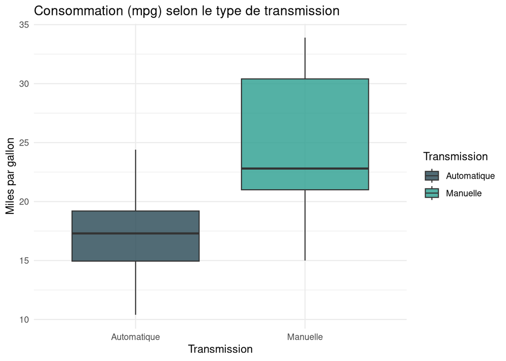

```r
# Graphique 1 : consommation selon la transmission

ggplot(donnees_clean, aes(x = transmission, y = mpg, fill = transmission)) +
  geom_boxplot(alpha = 0.8) +
  scale_fill_manual(values = c("#264653", "#2A9D8F")) +
  labs(
    title = "Consommation (mpg) selon le type de transmission",
    x = "Transmission",
    y = "Miles par gallon",
    fill = "Transmission"
  ) +
  theme_minimal()
```

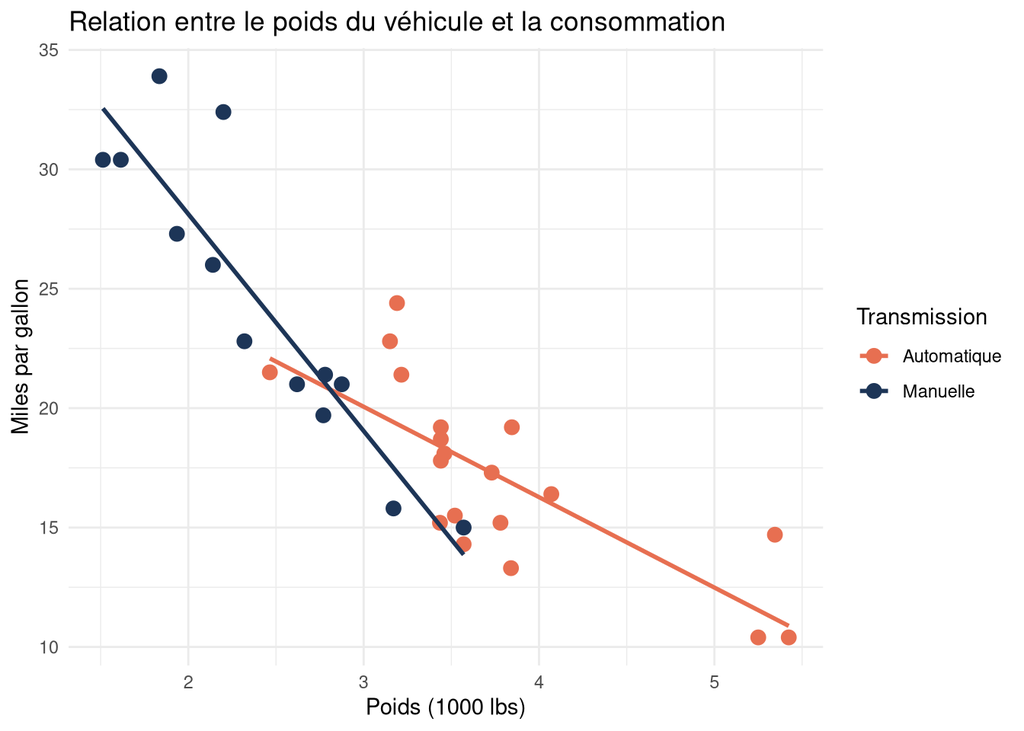

```r
# Graphique 2 : relation poids / consommation

ggplot(donnees_clean, aes(x = wt, y = mpg, color = transmission)) +
  geom_point(size = 3) +
  geom_smooth(method = "lm", se = FALSE) +
  scale_color_manual(values = c("#E76F51", "#1D3557")) +
  labs(
    title = "Relation entre le poids du véhicule et la consommation",
    x = "Poids (1000 lbs)",
    y = "Miles par gallon",
    color = "Transmission"
  ) +
  theme_minimal()
```

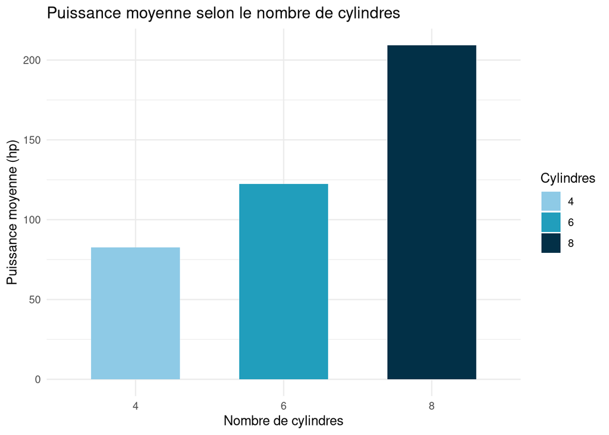

```r
# Graphique 3 : puissance moyenne par nombre de cylindres

donnees_clean %>%
  group_by(cylindres) %>%
  summarise(puissance_moyenne = mean(hp), .groups = "drop") %>%
  ggplot(aes(x = cylindres, y = puissance_moyenne, fill = cylindres)) +
  geom_col(width = 0.6) +
  scale_fill_manual(values = c("#8ECAE6", "#219EBC", "#023047")) +
  labs(
    title = "Puissance moyenne selon le nombre de cylindres",
    x = "Nombre de cylindres",
    y = "Puissance moyenne (hp)",
    fill = "Cylindres"
  ) +
  theme_minimal()
```

```r
# Graphique interactif plotly

graph_interactif <- ggplot(
  donnees_clean,
  aes(
    x = hp,
    y = mpg,
    color = transmission,
    text = paste(
      "Modèle :", modele,
      "<br>Puissance :", hp,
      "<br>Consommation :", mpg,
      "<br>Poids :", wt
    )
  )
) +
  geom_point(size = 3) +
  labs(title = "Consommation et puissance des véhicules") +
  theme_minimal()

ggplotly(graph_interactif, tooltip = "text")
```

[interactive chart not shown]

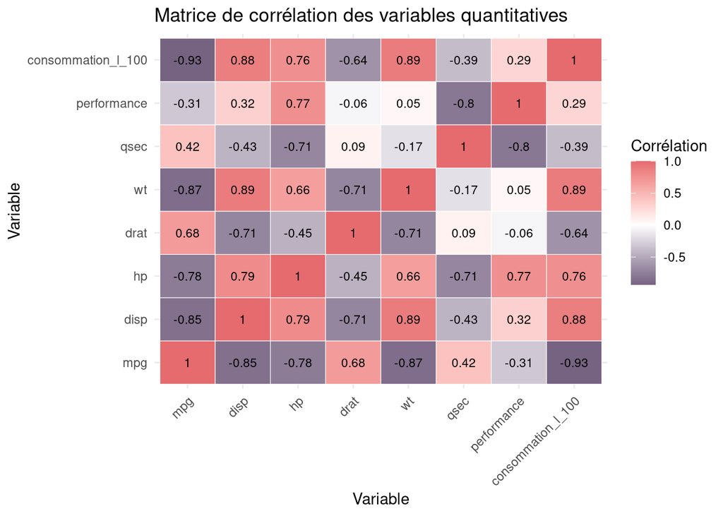

```r
# Matrice de corrélation visualisée

matrice_corr <- donnees_clean %>%
  select(mpg, disp, hp, drat, wt, qsec, performance, consommation_l_100) %>%
  cor()

matrice_corr_df <- as.data.frame(as.table(matrice_corr))

ggplot(matrice_corr_df, aes(Var1, Var2, fill = Freq)) +
  geom_tile(color = "white") +
  geom_text(aes(label = round(Freq, 2)), size = 3) +
  scale_fill_gradient2(low = "#6D597A", mid = "white", high = "#E56B6F", midpoint = 0) +
  labs(
    title = "Matrice de corrélation des variables quantitatives",
    x = "Variable",
    y = "Variable",
    fill = "Corrélation"
  ) +
  theme_minimal() +
  theme(axis.text.x = element_text(angle = 45, hjust = 1))
```

L’analyse visuelle met en évidence plusieurs tendances : les véhicules manuels sont globalement plus sobres, le poids dégrade fortement l’efficacité énergétique, et l’augmentation du nombre de cylindres s’accompagne d’une hausse de la puissance moyenne. La matrice de corrélation confirme le rôle central du poids, de la cylindrée et de la puissance.

## 3. Statistiques inférentielles

```r
# Test d'hypothèse : consommation selon la transmission

test_transmission <- t.test(mpg ~ transmission, data = donnees_clean)
test_transmission
```

```
##
##  Welch Two Sample t-test
##
## data:  mpg by transmission
## t = -3.7671, df = 18.332, p-value = 0.001374
## alternative hypothesis: true difference in means between group Automatique and group Manuelle is not equal to 0
## 95 percent confidence interval:
##  -11.280194  -3.209684
## sample estimates:
## mean in group Automatique    mean in group Manuelle
##                  17.14737                  24.39231
```

Le test t est pertinent ici car il compare la moyenne de consommation de deux groupes indépendants : véhicules automatiques et manuels. La p-value obtenue permet d’évaluer si l’écart observé est statistiquement significatif.

```r
# Régression linéaire multiple
# Variable cible : mpg
# Variables retenues : wt, hp, qsec, am
# Justification : ces variables couvrent le poids, la puissance,
# le comportement dynamique et le type de transmission.

modele_1 <- lm(mpg ~ wt + hp + qsec + am, data = donnees_clean)
summary(modele_1)
```

```
##
## Call:
## lm(formula = mpg ~ wt + hp + qsec + am, data = donnees_clean)
##
## Residuals:
##     Min      1Q  Median      3Q     Max
## -3.4975 -1.5902 -0.1122  1.1795  4.5404
##
## Coefficients:
##             Estimate Std. Error t value Pr(>|t|)
## (Intercept) 17.44019    9.31887   1.871  0.07215 .
## wt          -3.23810    0.88990  -3.639  0.00114 **
## hp          -0.01765    0.01415  -1.247  0.22309
## qsec         0.81060    0.43887   1.847  0.07573 .
## am           2.92550    1.39715   2.094  0.04579 *
## ---
## Signif. codes:  0 '***' 0.001 '**' 0.01 '*' 0.05 '.' 0.1 ' ' 1
##
## Residual standard error: 2.435 on 27 degrees of freedom
## Multiple R-squared:  0.8579, Adjusted R-squared:  0.8368
## F-statistic: 40.74 on 4 and 27 DF,  p-value: 4.589e-11
```

```r
# Modèle alternatif

modele_2 <- lm(mpg ~ wt + disp + cyl + am, data = donnees_clean)
summary(modele_2)
```

```
##
## Call:
## lm(formula = mpg ~ wt + disp + cyl + am, data = donnees_clean)
##
## Residuals:
##    Min     1Q Median     3Q    Max
## -4.318 -1.362 -0.479  1.354  6.059
##
## Coefficients:
##              Estimate Std. Error t value Pr(>|t|)
## (Intercept) 40.898313   3.601540  11.356 8.68e-12 ***
## wt          -3.583425   1.186504  -3.020  0.00547 **
## disp         0.007404   0.012081   0.613  0.54509
## cyl         -1.784173   0.618192  -2.886  0.00758 **
## am           0.129066   1.321512   0.098  0.92292
## ---
## Signif. codes:  0 '***' 0.001 '**' 0.01 '*' 0.05 '.' 0.1 ' ' 1
##
## Residual standard error: 2.642 on 27 degrees of freedom
## Multiple R-squared:  0.8327, Adjusted R-squared:  0.8079
## F-statistic: 33.59 on 4 and 27 DF,  p-value: 4.038e-10
```

```r
AIC(modele_1, modele_2)
```

```
##          df      AIC
## modele_1  6 154.3274
## modele_2  6 159.5471
```

```r
BIC(modele_1, modele_2)
```

```
##          df      BIC
## modele_1  6 163.1218
## modele_2  6 168.3415
```

```r
# Performance du modèle

predictions <- augment(modele_1, newdata = donnees_clean)
rmse_modele_1 <- sqrt(mean((predictions$.resid)^2))
r2_modele_1 <- summary(modele_1)$r.squared

cat("R² :", round(r2_modele_1, 3), "\n")
```

```
## R² : 0.858
```

```r
cat("RMSE :", round(rmse_modele_1, 3), "\n")
```

```
## RMSE : 2.237
```

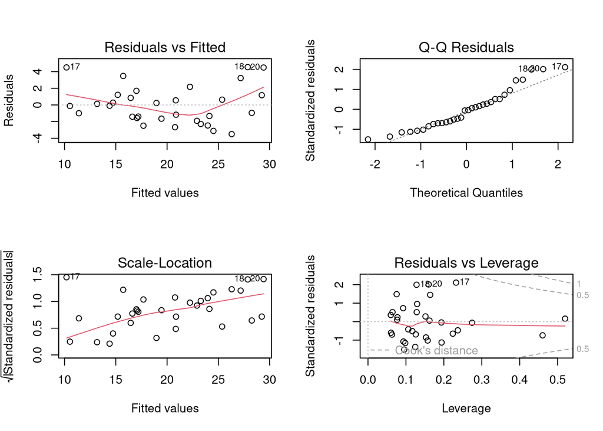

```r
# Diagnostic du modèle

par(mfrow = c(2, 2))
plot(modele_1)
```

```r
par(mfrow = c(1, 1))
```

Le modèle de régression multiple explique une part importante de la variabilité de la consommation. Le poids a un effet négatif clair sur `mpg`, tandis que la transmission manuelle semble associée à une meilleure efficacité. Le diagnostic graphique permet de vérifier visuellement les hypothèses du modèle, même si la taille réduite de l’échantillon impose de rester prudent dans la généralisation.

## 4. Conclusion business

### Limites de l’étude

- le dataset `mtcars` contient peu d’observations ;
- les véhicules analysés ne sont pas représentatifs du parc automobile actuel ;
- certaines variables importantes sont absentes : prix, émissions CO2, kilométrage réel, usage.

### Pistes d’amélioration

- enrichir l’analyse avec un dataset open data plus récent ;
- intégrer des variables économiques et environnementales ;
- comparer plusieurs modèles prédictifs ;
- approfondir la segmentation des véhicules par usage ou gamme.